# Bloque 4

Septiembre, 2017

## Temas

## Introducción

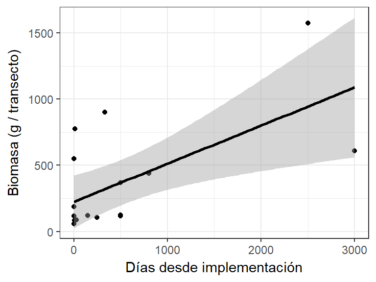

[output not shown]

## En realidad Matthews (2000)

[figure not shown]

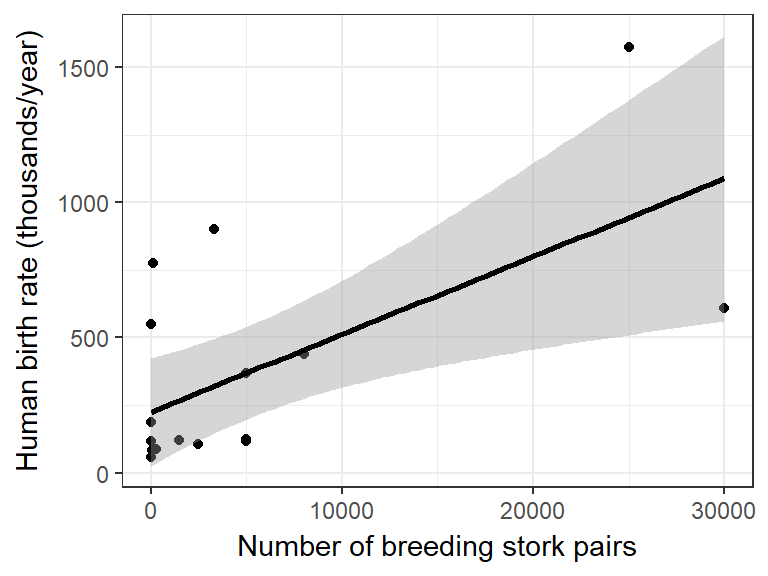

## *"Correlación no implica causalidad"*

## Análisis de MAREA

- Biológicos: Diferencia-en-Diferencia (efectos fijos, GLM)
- Socioeconómicos: Regresión lineal
- Gobernanza: Tabla de decisiones, literatura

## Biológicos

## ¿La reserva es efectiva?

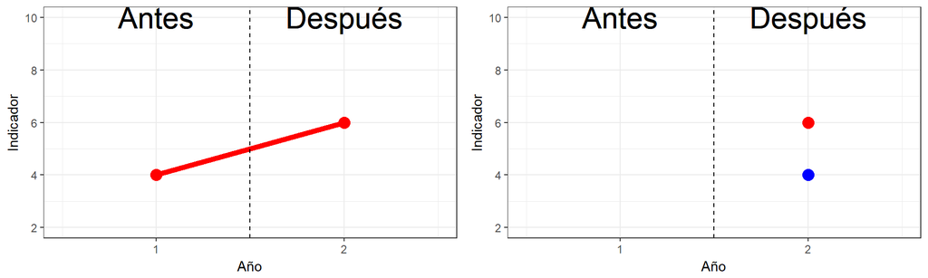

## ¿La reserva es efectiva?

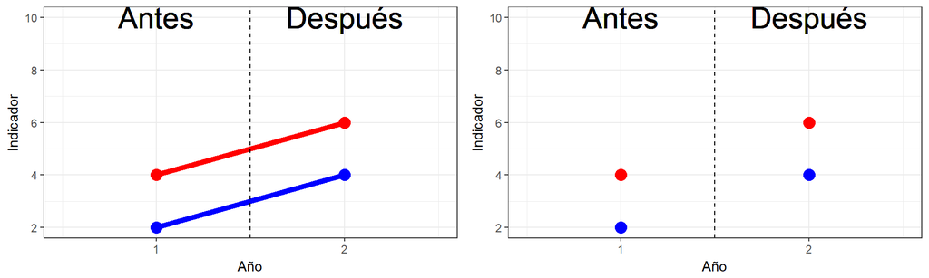

- Cambio reserva en el tiempo
- Diferencias entre reserva y control
- **Efecto neto de la reserva en el indicador**
  - Diferencia a través del tiempo **y** a través de tratamientos

## Diferencia-en-Diferencia

- Técnica de Econometría
- Utilizada en evaluación de impacto:
  - ¿Cuál es el efecto de una intervención de manejo?
    - Programa PROGRESA (Paul Schultz 2004)
    - Efecto ITQs (Costello, Gaines, and Lynham 2008)
    - Efecto RM en langosta y bacalao (Moland et al. 2013)
- Requiere diseño ADCI (BACI)
- \[DeD = \Delta_T - \Delta_C\]
- \[DeD = (T_d- T_a) - (C_d - C_a)\]

## Ejemplo

| Zona | Antes | Después | \(\Delta\) |
| --- | --- | --- | --- |
| Control | 2 | 4 | 2 |
| Reserva | 4 | 9 | 5 |
| \(\Delta\) | 2 | 5 | **3** |

## Automatizar con regresión

\[Indicador = \beta_0 + \beta_1Zona + \beta_2Post + \beta_3Zona\times Post+\epsilon\]

|  | *Dependent variable:* |
| --- | --- |
|  | Indicador |
| β<sub>0</sub> | 2.000 |
| β<sub>1</sub> | 2.000 |
| β<sub>2</sub> | 2.000 |
| β3 | 3.000 |
| Observations | 4 |
| R<sup>2</sup> | 1.000 |
| *Note:* | p<0.1; p<0.05; p<0.01 |

## Interpretación

\[Indicador = \beta_0 + \beta_1Zona + \beta_2Post + \beta_3Zona\times Post+\epsilon\]

- \(\beta_0\): Valor del Control Antes
- \(\beta_1\): Diferencia entre Reserva y Control, Antes
- \(\beta_2\): Diferencia entre Antes y Después Control
- \(\beta_3\): Diferencia entre Reserva esperada y observada (efecto neto de la reserva)

## Otra forma de verlo

\[Indicador = \beta_0 + \beta_1Zona + \beta_2Post + \beta_3Zona\times Post+\epsilon\]

- Antes Control = \(\beta_0\)
- Antes Reserva = \(\beta_0 + \beta_1\)
- Después Control = \(\beta_0 + \beta_2\)
- Después Reserva = \(\beta_0 + \beta_1 + \beta_2 + \beta_3\)

## En tabla

Antes Control = \(\beta_0\)

Antes Reserva = \(\beta_0 + \beta_1\)

Después Control = \(\beta_0 + \beta_2\)

Después Reserva = \(\beta_0 + \beta_1 + \beta_2 + \beta_3\)

**Entonces**

| Zona | Antes | Despues | \(\Delta\) |
| --- | --- | --- | --- |
| Control | \(\beta_0\) | \(\beta_0 + \beta_2\) | \(\beta_2\) |
| Reserva | \(\beta_0 + \beta_1\) | \(\beta_0 + \beta_1 + \beta_2 + \beta_3\) | \(\beta_2 + \beta_3\) |
| \(\Delta\) | \(\beta_1\) | \(\beta_1 + \beta_3\) | **\(\beta_3\)** |

## Pero yo tengo réplicas por año…

## Ejemplo varias observaciones

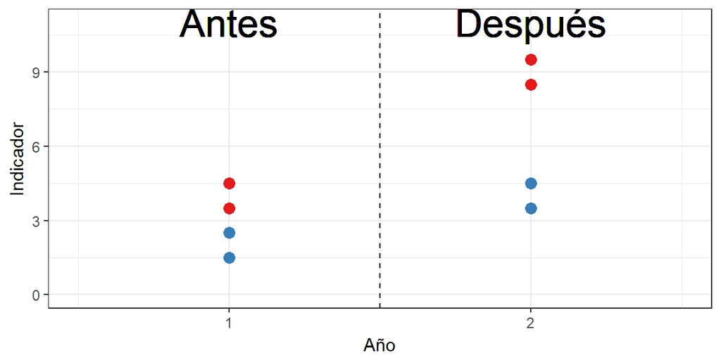

¡Es mejor!

## Ejemplo varias observaciones

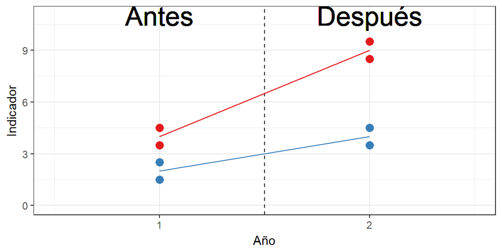

Los coeficientes tienden al promedio

## Ejemplo de varias observaciones

|  | *Dependent variable:* |
| --- | --- |
|  | Valor |
| β<sub>0</sub> | 2.000 (0.500)<sup>++</sup> |
| β<sub>1</sub> | 2.000 (0.707)<sup>++</sup> |
| β<sub>2</sub> | 2.000 (0.707)<sup>++</sup> |
| **β3** | 3.000 (1.000)<sup>++</sup> |
| Observations | 8 |
| R<sup>2</sup> | 0.964 |
| Adjusted R<sup>2</sup> | 0.937 |
| Residual Std. Error | 0.707 (df = 4) |
| F Statistic | 35.667<sup>+++</sup> (df = 3; 4) |
| Notes: | +p<0.1; ++p<0.05; +++p<0.01 |

- Podemos calcular errores estándar
- Prueba de hipótesis a todos los coeficientes (t student)

## DeD en MAREA

- \[Indicador = \beta_0 + \beta_1Post + \beta_2Zona + \beta_3Post\times Zona+\epsilon\]
- Más periodos de tiempo (Antes, Después, Después, Después, Después…)
- Cambios aditivos y multiplicativos
- \[I = \beta_0 + \sum_{i = 1}^n \gamma_iPost_i + \beta_2Zona + \beta_3Post\times Zona + \omega +\epsilon\]
- **\(\beta_3\)** sigue siendo el efecto neto de la reserva en el indicador
- Errores estándar robustos a datos heterocedásticos

## DeD en MAREA

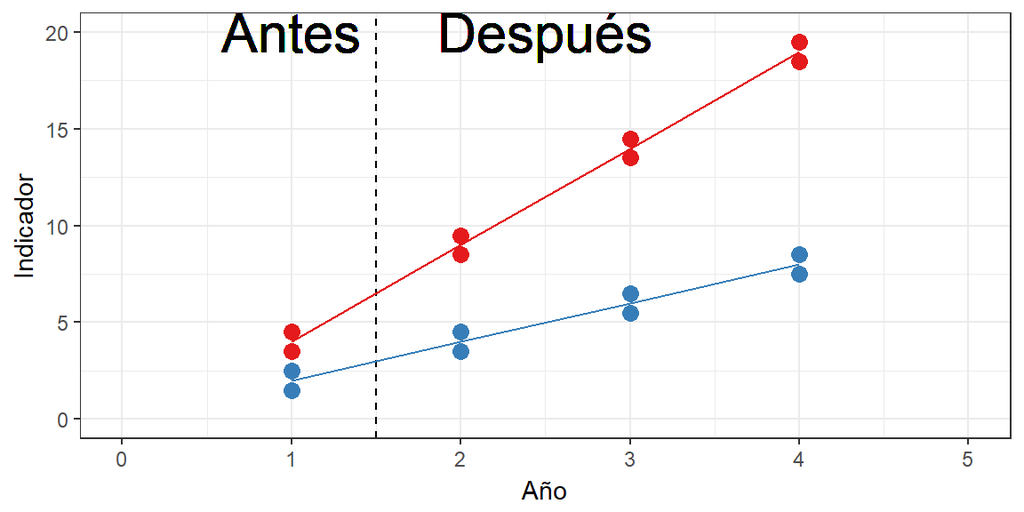

## DeD en MAREA

|  | *Dependent variable:* |
| --- | --- |
|  | Valor |
| β<sub>0</sub> | 2.00 (1.05)<sup>+</sup> |
| γ<sub>1</sub> | 0.50 (1.35) |
| γ<sub>2</sub> | 4.00 (1.35)<sup>++</sup> |
| γ<sub>3</sub> | 7.50 (1.35)<sup>+++</sup> |
| β<sub>1</sub> | 2.00 (1.48) |
| **β<sub>3</sub>** | 6.00 (1.71)<sup>+++</sup> |
| Observations | 16 |
| R<sup>2</sup> | 0.95 |
| Adjusted R<sup>2</sup> | 0.93 |
| Residual Std. Error | 1.48 (df = 10) |
| F Statistic | 40.09<sup>+++</sup> (df = 5; 10) |
| Notes: | +p<0.1; ++p<0.05; +++p<0.01 |

## Covariables para mejorar ajuste

\[\omega = \beta_4Temp + \beta_5Prof + \beta_6Vis\]

- Temperatura del agua durante el transecto
- Profundidad del transecto
- Visibilidad (horizontal) durante el transecto

## Covariables para mejorar ajuste

## ¿Y si no tengo covariables?

| Año | Zona | Biomasa | Temp | Prof | Vis |
| --- | --- | --- | --- | --- | --- |
| 2010 | Control | 0.27 | 20 | 14 | NA |
| 2010 | Reserva | 0.37 | NA | 15 | 4 |
| 2011 | Control | 0.57 | 19 | NA | 5 |
| 2011 | Reserva | 0.91 | 21 | 12 | 9 |

- No se midió antes
- Al buzo se le olvidó registrar profundidad
- La computadora no marcaba Temperatura
- Normalmente, se eliminaría el registro entero

## MAREA y NAs

- Evalúa proporción de datos con NA para cada punto de muestreo
  - Antes Reserva
  - Antes Control
  - Después Reserva
  - Después Control
- Si incluir una covariable implica perder más del 10% de los datos, mejor eliminar covariable

## \(\beta_3\)

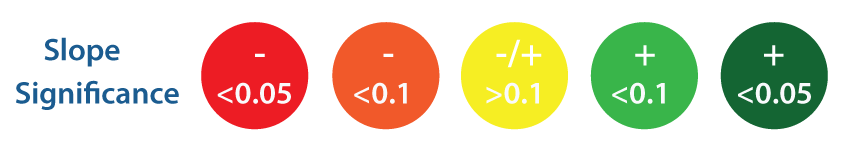

- \(\beta_3\) es nuestro valor del efecto neto de la reserva
- Se usa en la tabla de puntajes para definir:
  - color (sentido)
  - intensidad (significancia)

## Socioeconómicos

## Falta de control

- Por la naturaleza de los datos, no existe una "comunidad control"
- Necesitaríamos una comunidad idéntica pero **SIN** reservas
- Aún podemos extraer información útil

## Modelo socioeconómico

\[I = \beta_1Post + \beta_0\] - Comparación antes - después de los datos - \[\beta_1\] me indica la diferencia entre promedio antes y después - IPC para normalizar ingresos (usuario debe incluir estos valores) - Disponibles en [OECD](https://data.oecd.org/price/inflation-cpi.htm)

## Normalizar ingresos

\[IN_t = IR\times \frac{IPC_t}{CPI_T}\] - \(IN\): ingreso normalizado - \(IR\): ingreso reportado - \(IPC_t\): índice de precio al consumidor en el año \(t\) - \(IPC_T\): índice de precio al consumidor en el último año (\(T\))

## Ejemplo

| t | IR | IPC | IPCt/IPCT | IN |
| --- | --- | --- | --- | --- |
| 2010 | 130.51 | 4.16 | 1.03 | 135 |
| 2011 | 159.22 | 3.41 | 0.85 | 135 |
| 2012 | 131.84 | 4.12 | 1.02 | 135 |
| 2013 | 142.53 | 3.81 | 0.95 | 135 |
| 2014 | 135.00 | 4.02 | 1.00 | 135 |

## Ejemplo

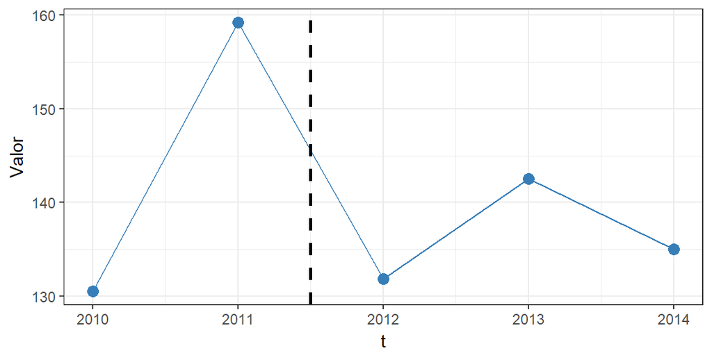

## Ejemplo

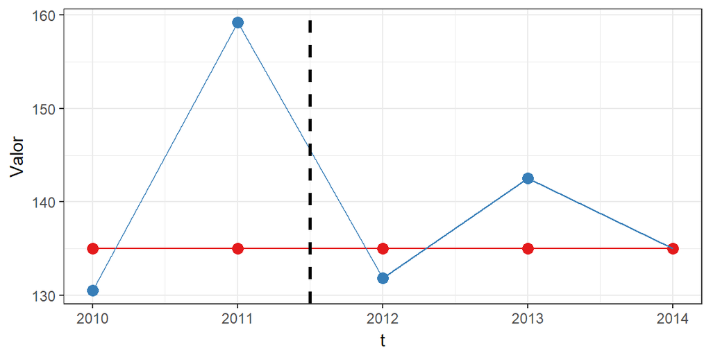

## Ejemplo

|  | *Dependent variable:* |  |
| --- | --- | --- |
|  | IR | IN |
|  | (1) | (2) |
| β<sub>0</sub> | 144.87 (8.87)*** | 135.00 (0.0000)*** |
| β<sub>1</sub> | -8.41 (11.45) | 0.0000 (0.0000) |
| Observations | 5 | 5 |
| R<sup>2</sup> | 0.15 | 0.27 |
| Adjusted R<sup>2</sup> | -0.13 | 0.02 |
| Residual Std. Error (df = 3) | 12.55 | 0.0000 |
| F Statistic (df = 1; 3) | 0.54 | 1.09 |
| *Note:* | p<0.1; p<0.05; p<0.01 |  |

## \(\beta_1\)

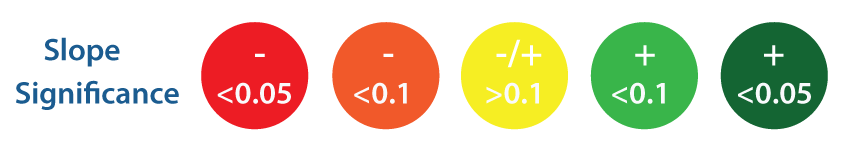

- \(\beta_1\) indica diferencia entre antes y después
- Se usa en la tabla de puntajes para definir:
  - color (sentido)
  - intensidad (significancia)

## Gobernanza

- Indicadores de cambio
  - Nivel de pesca ilegal (antes vs. ahora)
  - Número de pescadores (antes vs. ahora)
  - Se analizan según literatura (bueno = verde, malo = rojo)
- Algunos indicadores son narrativos
  - *e.g.* "Razonamiento para la localización de la reserva"
  - No se analizan, pero se incluye la narrativa en el reporte
- Resumen con gráficos en el reporte generado por MAREA

## Referencias

Costello, Christopher, Steven D Gaines, and John Lynham. 2008. “Can Catch Shares Prevent Fisheries Collapse?” *Science* 321 (5896): 1678–81. doi:10.1126/science.1159478.

Matthews, Robert. 2000. “Storks Deliver Babies (P = 0.008).” *Teach Stat* 22 (2): 36–38. doi:10.1111/1467-9639.00013.

Moland, Even, Esben Moland Olsen, Halvor Knutsen, Pauline Garrigou, Sigurd Heiberg Espeland, Alf Ring Kleiven, Carl André, and Jan Atle Knutsen. 2013. “Lobster and Cod Benefit from Small-Scale Northern Marine Protected Areas: Inference from an Empirical Before-After Control-Impact Study.” *Proc Biol Sci* 280 (1754): 20122679. doi:10.1098/rspb.2012.2679.

Paul Schultz, T. 2004. “School Subsidies for the Poor: Evaluating the Mexican Progresa Poverty Program.” *J Dev Econ* 74 (1): 199–250. doi:10.1016/j.jdeveco.2003.12.009.

## Bloque 5